# CP06_2

Valentina Díaz Torres

13/12/2020

## Introducción

En la segunda parte del caso de BMW y Volkswagen se va a estudiar la cointegración entre ambas marca.

```r
#carga de librerías

library(quantmod)
library(forecast)
library("fGarch")
library(vars)
require(devtools)
library(dplyr)
library(tidyr)
library(imputeTS)
library(ggplot2)
library(urca)
library(PairTrading)
#install_version("PairTrading", version = "1.1", repos = "http://cran.us.r-project.org")
```

```r
start = "2014-01-01"
end = "2020-12-24"

vol<- getSymbols("VOW.DE",
                 from = start,
                 to= end,
                 auto.assign = FALSE)



vol <- vol[, 6]
colnames(vol) <- "precio"

vol %>%
  is.na() %>%
  sum()
```

```
## [1] 2
```

```r
vol <- vol  %>%
  na_locf()

bmw <- getSymbols ("BMW.DE",
                   from = start,
                   to= end,
                   auto.assign = FALSE)

bmw <- bmw[, 6]
colnames(bmw) <- "precio"

bmw %>%
  is.na() %>%
  sum()
```

```
## [1] 2
```

```r
bmw <- bmw  %>%
  na_locf()
```

Para que dos series estén cointegradas, ambas deberían ser estacionarias, es decir que sus errores los sea. Para comprobar esto se usa el test de Dickey-Fuller, que parte de la HO: ambas series no son estacionarias. Por lo que habrá que comprobar si lo son o no.

Hacemos el test inicial para comprobar la cointegración, el número de lags es igual a 0

```r
test_bmw0<-ur.df(bmw,type="none",selectlags="AIC",lags=0)
test_vol0<-ur.df(bmw,type="trend",selectlags="AIC",lags=0)
summary(test_bmw0)
```

```
##
## ###############################################
## # Augmented Dickey-Fuller Test Unit Root Test #
## ###############################################
##
## Test regression none
##
##
## Call:
## lm(formula = z.diff ~ z.lag.1 - 1)
##
## Residuals:
##     Min      1Q  Median      3Q     Max
## -6.2180 -0.5732 -0.0036  0.5669  5.4566
##
## Coefficients:
##           Estimate Std. Error t value Pr(>|t|)
## z.lag.1 -6.556e-05  3.850e-04   -0.17    0.865
##
## Residual standard error: 1.105 on 1760 degrees of freedom
## Multiple R-squared:  1.648e-05,  Adjusted R-squared:  -0.0005517
## F-statistic: 0.029 on 1 and 1760 DF,  p-value: 0.8648
##
##
## Value of test-statistic is: -0.1703
##
## Critical values for test statistics:
##       1pct  5pct 10pct
## tau1 -2.58 -1.95 -1.62
```

```r
summary(test_vol0)
```

```
##
## ###############################################
## # Augmented Dickey-Fuller Test Unit Root Test #
## ###############################################
##
## Test regression trend
##
##
## Call:
## lm(formula = z.diff ~ z.lag.1 + 1 + tt)
##
## Residuals:
##     Min      1Q  Median      3Q     Max
## -6.3969 -0.5776  0.0000  0.5659  5.1681
##
## Coefficients:
##               Estimate Std. Error t value Pr(>|t|)
## (Intercept)  7.931e-01  2.564e-01   3.093  0.00201 **
## z.lag.1     -1.078e-02  3.452e-03  -3.123  0.00182 **
## tt          -6.389e-05  5.496e-05  -1.163  0.24518
## ---
## Signif. codes:  0 '***' 0.001 '**' 0.01 '*' 0.05 '.' 0.1 ' ' 1
##
## Residual standard error: 1.103 on 1758 degrees of freedom
## Multiple R-squared:  0.005523,   Adjusted R-squared:  0.004392
## F-statistic: 4.882 on 2 and 1758 DF,  p-value: 0.007685
##
##
## Value of test-statistic is: -3.1229 3.2647 4.882
##
## Critical values for test statistics:
##       1pct  5pct 10pct
## tau3 -3.96 -3.41 -3.12
## phi2  6.09  4.68  4.03
## phi3  8.27  6.25  5.34
```

Luego el número de lags pasa a ser 1

```r
#Test bmw

test_bmw1<-ur.df(bmw,type="none",selectlags="AIC",lags=1)
summary(test_bmw1)
```

```
##
## ###############################################
## # Augmented Dickey-Fuller Test Unit Root Test #
## ###############################################
##
## Test regression none
##
##
## Call:
## lm(formula = z.diff ~ z.lag.1 - 1 + z.diff.lag)
##
## Residuals:
##     Min      1Q  Median      3Q     Max
## -6.2332 -0.5814 -0.0083  0.5726  5.5347
##
## Coefficients:
##              Estimate Std. Error t value Pr(>|t|)
## z.lag.1    -7.867e-05  3.848e-04  -0.204   0.8380
## z.diff.lag  5.221e-02  2.382e-02   2.191   0.0286 *
## ---
## Signif. codes:  0 '***' 0.001 '**' 0.01 '*' 0.05 '.' 0.1 ' ' 1
##
## Residual standard error: 1.104 on 1758 degrees of freedom
## Multiple R-squared:  0.002742,   Adjusted R-squared:  0.001607
## F-statistic: 2.417 on 2 and 1758 DF,  p-value: 0.0895
##
##
## Value of test-statistic is: -0.2045
##
## Critical values for test statistics:
##       1pct  5pct 10pct
## tau1 -2.58 -1.95 -1.62
```

```r
test_bmw2<-ur.df(bmw,type="trend",selectlags="AIC",lags=1)
summary(test_bmw2)
```

```
##
## ###############################################
## # Augmented Dickey-Fuller Test Unit Root Test #
## ###############################################
##
## Test regression trend
##
##
## Call:
## lm(formula = z.diff ~ z.lag.1 + 1 + tt + z.diff.lag)
##
## Residuals:
##     Min      1Q  Median      3Q     Max
## -6.4238 -0.5802 -0.0031  0.5594  5.2386
##
## Coefficients:
##               Estimate Std. Error t value Pr(>|t|)
## (Intercept)  8.341e-01  2.569e-01   3.246  0.00119 **
## z.lag.1     -1.136e-02  3.459e-03  -3.284  0.00105 **
## tt          -6.639e-05  5.498e-05  -1.208  0.22737
## z.diff.lag   5.770e-02  2.382e-02   2.422  0.01552 *
## ---
## Signif. codes:  0 '***' 0.001 '**' 0.01 '*' 0.05 '.' 0.1 ' ' 1
##
## Residual standard error: 1.101 on 1756 degrees of freedom
## Multiple R-squared:  0.008807,   Adjusted R-squared:  0.007114
## F-statistic: 5.201 on 3 and 1756 DF,  p-value: 0.00141
##
##
## Value of test-statistic is: -3.2835 3.6048 5.3949
##
## Critical values for test statistics:
##       1pct  5pct 10pct
## tau3 -3.96 -3.41 -3.12
## phi2  6.09  4.68  4.03
## phi3  8.27  6.25  5.34
```

```r
#Test Volskwagen
test_vol1<-ur.df(vol,type="none",selectlags="AIC",lags=1)
summary(test_vol1)
```

```
##
## ###############################################
## # Augmented Dickey-Fuller Test Unit Root Test #
## ###############################################
##
## Test regression none
##
##
## Call:
## lm(formula = z.diff ~ z.lag.1 - 1 + z.diff.lag)
##
## Residuals:
##      Min       1Q   Median       3Q      Max
## -24.6084  -1.4409   0.0287   1.4999  12.5714
##
## Coefficients:
##              Estimate Std. Error t value Pr(>|t|)
## z.lag.1    -0.0002405  0.0004500  -0.534    0.593
## z.diff.lag  0.0574573  0.0238218   2.412    0.016 *
## ---
## Signif. codes:  0 '***' 0.001 '**' 0.01 '*' 0.05 '.' 0.1 ' ' 1
##
## Residual standard error: 2.76 on 1758 degrees of freedom
## Multiple R-squared:  0.003449,   Adjusted R-squared:  0.002316
## F-statistic: 3.042 on 2 and 1758 DF,  p-value: 0.04797
##
##
## Value of test-statistic is: -0.5344
##
## Critical values for test statistics:
##       1pct  5pct 10pct
## tau1 -2.58 -1.95 -1.62
```

```r
test_vol2<-ur.df(vol,type="trend",selectlags="AIC",lags=1)
summary(test_vol2)
```

```
##
## ###############################################
## # Augmented Dickey-Fuller Test Unit Root Test #
## ###############################################
##
## Test regression trend
##
##
## Call:
## lm(formula = z.diff ~ z.lag.1 + 1 + tt + z.diff.lag)
##
## Residuals:
##      Min       1Q   Median       3Q      Max
## -24.6051  -1.4631  -0.0123   1.4598  12.1975
##
## Coefficients:
##               Estimate Std. Error t value Pr(>|t|)
## (Intercept)  1.161e+00  4.616e-01   2.514  0.01202 *
## z.lag.1     -8.092e-03  2.939e-03  -2.753  0.00596 **
## tt           1.476e-06  1.309e-04   0.011  0.99100
## z.diff.lag   6.130e-02  2.383e-02   2.572  0.01019 *
## ---
## Signif. codes:  0 '***' 0.001 '**' 0.01 '*' 0.05 '.' 0.1 ' ' 1
##
## Residual standard error: 2.756 on 1756 degrees of freedom
## Multiple R-squared:  0.007683,   Adjusted R-squared:  0.005988
## F-statistic: 4.532 on 3 and 1756 DF,  p-value: 0.003591
##
##
## Value of test-statistic is: -2.7534 2.5968 3.8897
##
## Critical values for test statistics:
##       1pct  5pct 10pct
## tau3 -3.96 -3.41 -3.12
## phi2  6.09  4.68  4.03
## phi3  8.27  6.25  5.34
```

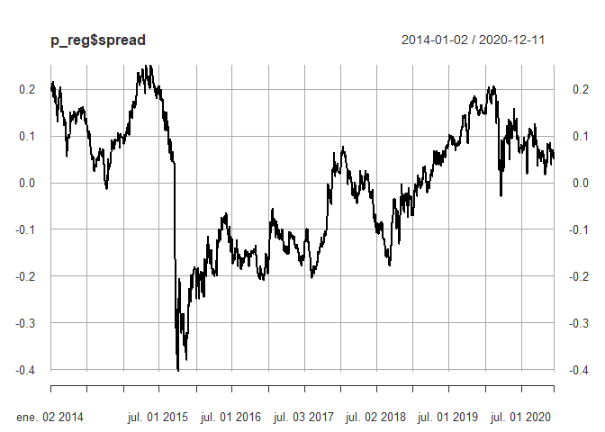

```r
#combinar las series
bmw_vol <- cbind(bmw, vol$precio)

#parámetros de regresión
p_reg <- EstimateParameters(bmw_vol, method = lm)

#visualización

plot(p_reg$spread)
```

Más tarde, es necesario verificar si el error es estacionario para finalmente decir que es o no estacionario.

```r
IsStationary(p_reg$spread, threshold = 0.05)
```

```
##  PP.test adf.test
##    FALSE    FALSE
```

El resultado obtenido ha sido que es falso, en ambos tests que el error sea estacionario. Por ello, se rechaza la cointegración entre BMW y Volkswagen.

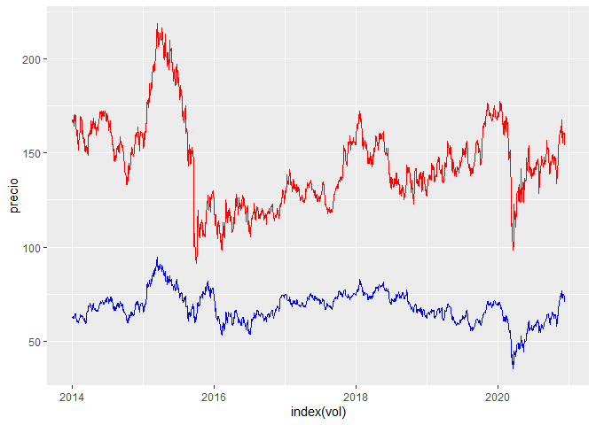

```r
ggplot()+
  geom_line(data = vol,
            aes(x = index(vol),
                y = precio),
            color = "red") +
  geom_line(data = bmw,
            aes(x = index(vol),
                y = precio),
            color = "blue")
```